# HRV analysis

## Calculate the maximum Lyapunov exponent

The most notable characteristic of a chaotic system is its sensitivity to initial conditions. This means that any two trajectories starting out very close to each other will separate exponentially fast in time. This sensitivity to initial conditions is usually quantified as:

$$\delta(t) \approx \delta(0) \cdot exp(\lambda t),$$

where $\delta(0)$ is the initial distance between two close points in phase space (thus, I assume that $\delta(0)$ is small), $\delta(t)$ is their distance at time $t$, and $\lambda$ is the average divergence rate of close trajectories in the system. $\lambda$ is called the maximal Lyapunov exponent and is a measure of the rate of divergence of close trajectories in the phase space. $\lambda$ is thus defined as the maximal Lyapunov exponent.

$$\lambda(t) \approx log[\delta(t)/\delta(o)],$$

Thus, to estimate the Lyapunov exponent of a system, a linear regression of $S(t)=log ??(t)/??(0)$ on tis usually performed.In practical applications, one should check for the existence of a linear region when representing $S(t)$ against $t$. If for some temporal range this plot shows a linear behavior, its slope is an estimate of the maximal Lyapunov exponent per unit of time. If such a region does not exist, the estimation should be discarded.

Under some general restrictions, the Lyapunov exponent becomes a well-defined invariant quantity of the dynamical system. Thus, just like for the generalized dimension estimates, the maximal Lyapunov exponent should be computed for several embedding dimensions in order to check that it does not depend on the embedding dimension and that the quantity is, indeed, invariant.

The radius parameter was selected based on the correlation sum (the correlation sum C(r) is the mean probability of finding a neighbor in a ball of radius r).

```
##  Computing the divergence of the time series
```

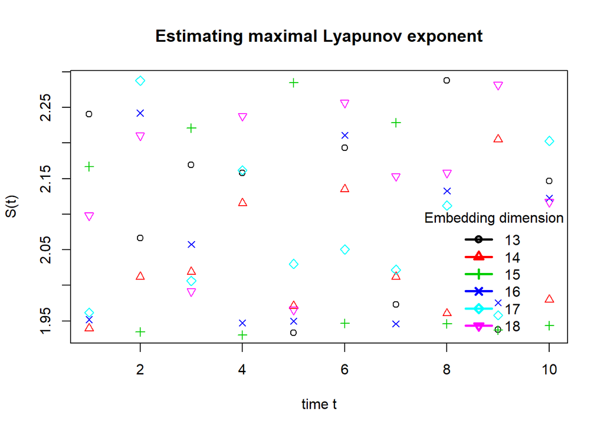

```r
hrv.data.dn = CalculateMaxLyapunov(hrv.data.dn, minRefPoints = 500, indexNonLinearAnalysis = 2,
                             minEmbeddingDim = kEmbeddingDim,
                             maxEmbeddingDim = kEmbeddingDim+5, timeLag = kTimeLag, radius = 60,
                             theilerWindow = 200, doPlot = TRUE, numberTimeSteps = 10)
```

```
##  Computing the divergence of the time series
```

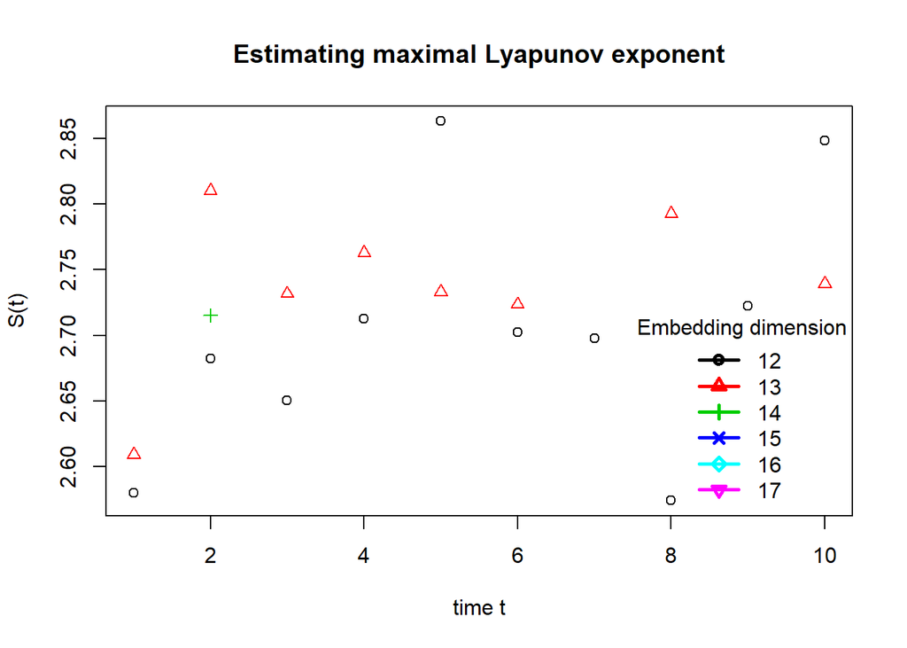

```r
hrv.data.dn.HI = CalculateMaxLyapunov(hrv.data.dn.HI, minRefPoints = 500, indexNonLinearAnalysis = 2,
                             minEmbeddingDim = kEmbeddingDim.HI,
                             maxEmbeddingDim = kEmbeddingDim.HI+5, timeLag = kTimeLag.HI, radius = 60,
                             theilerWindow = 200, doPlot = TRUE, numberTimeSteps = 10)
```

```
##  Computing the divergence of the time series
```

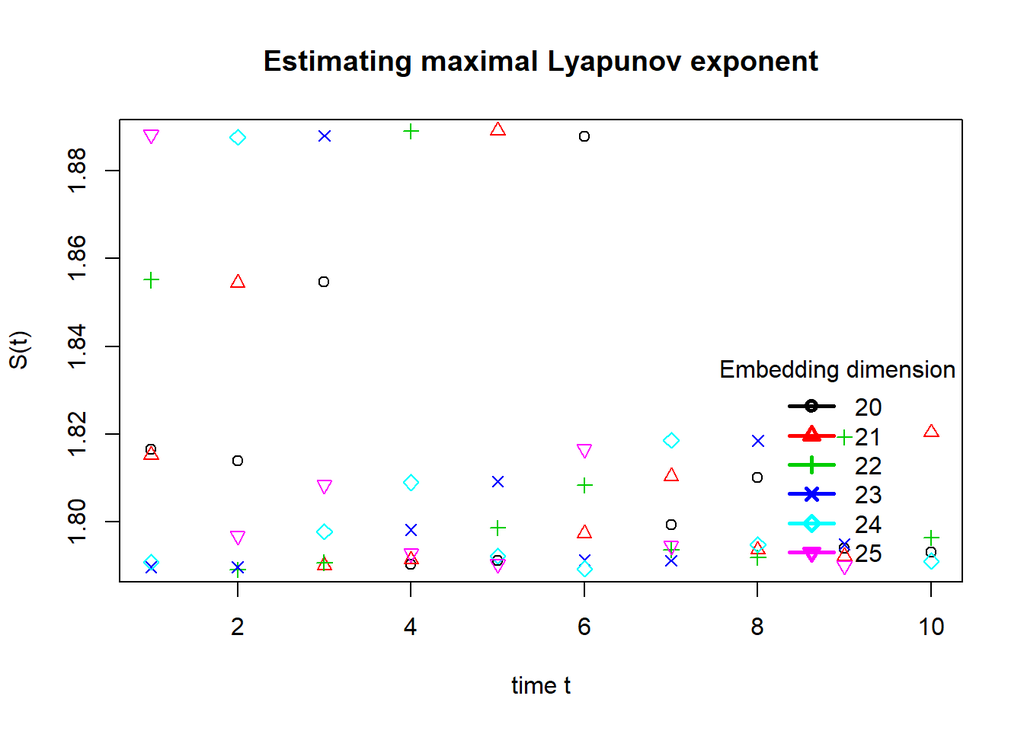

```r
hrv.data.dn.inf = CalculateMaxLyapunov(hrv.data.dn.inf, minRefPoints = 500, indexNonLinearAnalysis = 2,
                             minEmbeddingDim = kEmbeddingDim.inf,
                             maxEmbeddingDim = kEmbeddingDim.inf+5, timeLag = kTimeLag.inf, radius = 60,
                             theilerWindow = 200, doPlot = TRUE, numberTimeSteps = 10)
```

## Perform a Recurrence Quantification Analysis

The recurrence quantification analysis $(RQA)$ quantifies the number and duration of the recurrences in the phase space. A recurrence is the return of the trajectory in phase space to a neighborhood of a region that was visited before. $RQA$ requires the computation of the recurrence matrix:

$$Mi,j(r) = \Theta(r - ||x_i - x_j_ \{infty}),$$

where $x_i$ and $x_j$ are the phase space vectors, $r$ is a small radius that defines the size of the neighborhood, and $\Theta(\bullet)$ is the Heaviside function. Thus, if a point $(i, j)$ is marked as recurrent, this means that the state of the system at time $i$ has some similarity with the state of the system at time $j$. The degree of similarity is measured through the radius $r$.

The graphical representation of the recurrence matrix is usually referred to as recurrence plot $(RP)$. The appearance of a $RP$ provides evidence about the dynamical properties of the system. For example, a homogeneous $RP$ indicates stationarity. Furthermore, if the $RP$ is homogeneous in a small block of the plot, a stationary behavior can be assumed for the corresponding time period.

Vertical and horizontal lines indicate a time segment in which a state does not change or changes very slowly. Diagonal lines occur when a segment of a trajectory visits the same region of the phase space at different times. Therefore, parallel and perpendicular lines to the main diagonal are a strong sign of periodicity or determinism. For periodic or almost-periodic signals, the distance between parallel lines corresponds to the period The presence of white bands in the $RP$ is usually due to abrupt changes in the dynamics that lead to rare events. This is a strong sign of nonstationarity. Rare events and strong fluctuations may also appear as single isolated points in the $RP$s.

To quantify the presence of these visual patterns in $RP$s, Zbilut et al. proposed the use of some simple statistics that can be extracted from the recurrence matrix. The characterization of the recurrence matrix through these statistics is what receives the name of recurrence quantification analysis $(RQA)$.

The simplest measure that can be extracted from the recurrence matrix is the recurrence rate $REC$:

$$REC = \frac{1}{N^2}\sum^N_{i,j=1} M_{i,j}(r),$$

where $N$ is the number of points on the phase space trajectory. The recurrence rate is a measure of the density of the recurrent points in the $RP$. $RQA$ is usually applied to sparse recurrence matrices, and therefore, the recurrence rate must be kept low (e.g., from 0.1 to 2.0%). The recurrence rate can also be computed separately for each diagonal parallel to the main diagonal of the recurrence matrix at a given distance $??.$ The resulting statistic is referred to as the t-recurrence rate:

$$REC_t = \frac{1}{N-t} \sum^{N-t}_i=1}M_{i,i+t}(r)$$

The t-recurrence rate may be interpreted as the probability that a state returns to its neighborhood after $??$ steps. The trend statistic is an useful $RQA$ measure based on the t-recurrence rate. The trend is a linear regression coefficient obtained when considering a linear relation between $RECt$ and $t$:

$$TREND= \frac{\sum^{N}_{t= i}(t-N/2)(REC_t-\overline{REC_t})}{\sum^N_{t=1}(t-N/2)^2}$$

where $\overline{REC}_t$ is the mean $REC_t$ value and $N ~$ defines the maximal number of diagonals parallel to the main diagonal which will be used for computing the trend. The trend provides information about the stationarity of the process. In a stationary system, the recurrent points are homogeneously distributed across the RP. Hence, the trend will be near zero.

Weakly correlated processes, with stochastic or chaotic dynamics, generate RPs with small diagonal lines and isolated recurrent points, whereas deterministic processes usually generate longer diagonal lines. Thus, the ratio of recurrence points that form diagonals to all the recurrent points is a good measure of determinism. Thus, the determinism parameter is defined as:

$$DET = \frac{\sum^{N}_{l=l_min} l \cdot P(l)}{\sum^{N}_{i,j=1} M_{i,j}(r)}$$

where $P(l)$ is the number of diagonal segments of length $l$. The diagonal segments must have a minimum length $lmin$, otherwise they are excluded.

Another statistic related to diagonal lines is the ratio, defined as the ratio between $DET$ and $REC$. The ratio has proved useful for detecting transitions between physiological states]. During transitions, the number of recurrent points usually decreases, whereas the proportion of points in diagonal lines is less affected. Hence, the ratio increases during dynamical transitions.

A diagonal line with length $l$ implies that a segment of a trajectory is close to another segment (occurring at a different time) during $l$ time steps. Thus, the length of the diagonal lines depends on the rate of divergence of close trajectories in phase space. The average diagonal line length.
$$L = \frac{\sum^{N}_{l=l_min} l \cdot P(l)}{\sum^{N}_{i,j=1} P(l)}$$
may be interpreted as the mean time that two segments of the trajectory are closed to each other. Other $RQA$ measures related with diagonal lines are the length of the longest diagonal line Lmax , and its inverse, the divergence $DIV = 1$ .

Since the lengths of $L_{max}$ the diagonal lines are related to the divergence time of close trajectories, $L_{max}$ and $DIV$ are related to the maximal Lyapunov exponent. $DIV$ scales proportionally with the maximal Lyapunov exponent, whereas $L_{max}$ scales inversely.

The Shannon entropy of the probability $p(l)$ to find a diagonal line of length $l$,

$$ENTR = - \sum^{N}_{l=lmin}p(l) log p(l)$$
is a measure of the signal’s complexity. A large entropy is typical of chaotic systems, whereas a low entropy indicates either a periodic signal (since all its diagonal lines are long) or a uncorrelated noise (all its diagonal lines are small). It is possible to define analogous statistics to quantify the presence of vertical lines. The ratio between the recurrent points forming vertical lines and the entire set of recurrent points is called laminarity:

$$LAM = \frac{\sum^{N}_{v=v_min} v \cdot P(v)}{\sum^{N}_{i,j=1} M_{i,j}(r)}$$
The average length of the vertical lines is referred to as the trapping time:

$$TT = \frac{\sum^{N}_{v=v_min} v \cdot P(v)}{\sum^{N}_{i,j=1} P(v)}$$

, and it is related with the mean time that the system spends trapped in some state. Finally, the length of the longest vertical line, Vmax may be interpreted as the maximum time that the system spends trapped in a state.

```
##  Performing Recurrence Quantification Analysis
```

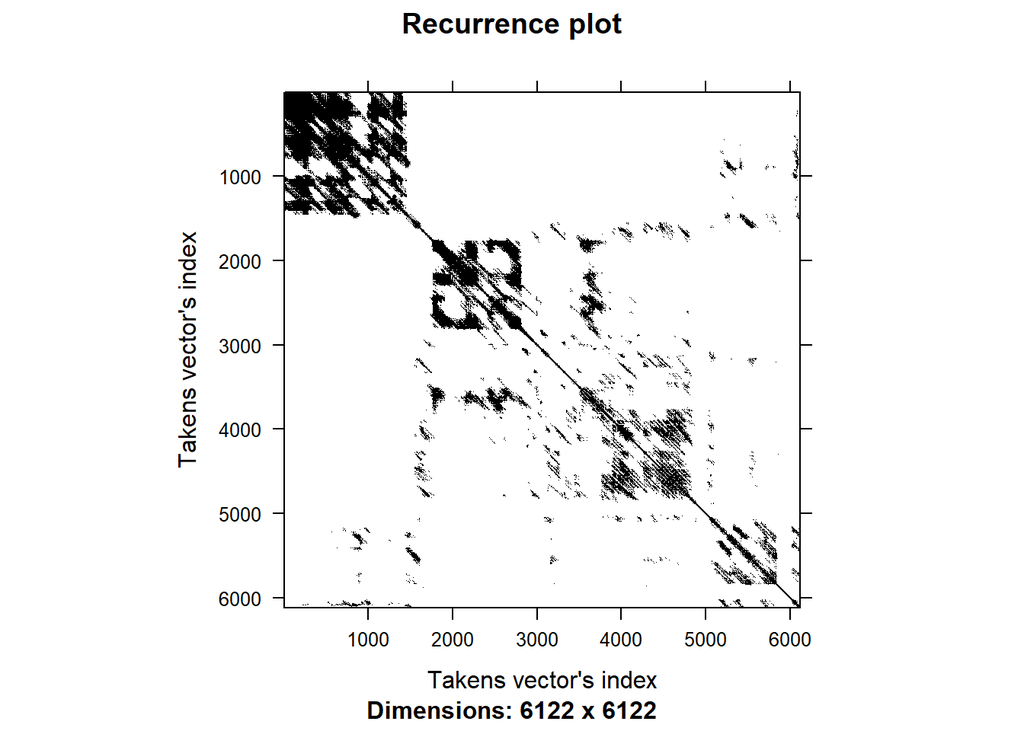

```r
hrv.data.dn = RQA(hrv.data.dn, indexNonLinearAnalysis = 2, embeddingDim = kEmbeddingDim, timeLag = kTimeLag, radius = 5, doPlot = TRUE)
```

```
##  Performing Recurrence Quantification Analysis
```

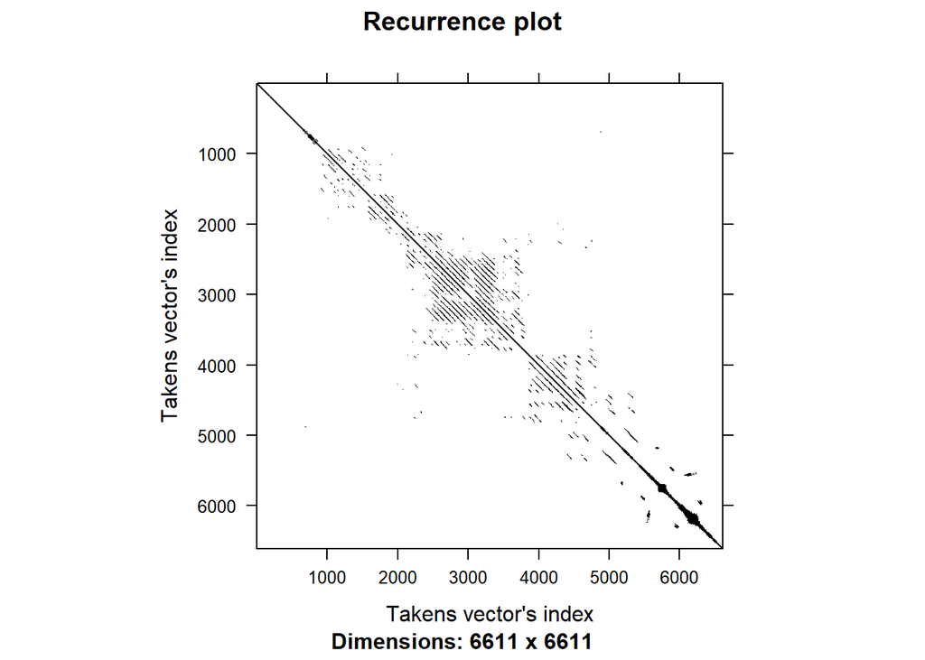

```r
rqa_pre <- (hrv.data.dn$NonLinearAnalysis[[2]]$rqa[1:12])
hrv.data.dn.HI = RQA(hrv.data.dn.HI, indexNonLinearAnalysis = 2, embeddingDim = kEmbeddingDim.HI, timeLag = kTimeLag.HI, radius = 5, doPlot = TRUE)
```

```
##  Performing Recurrence Quantification Analysis
```

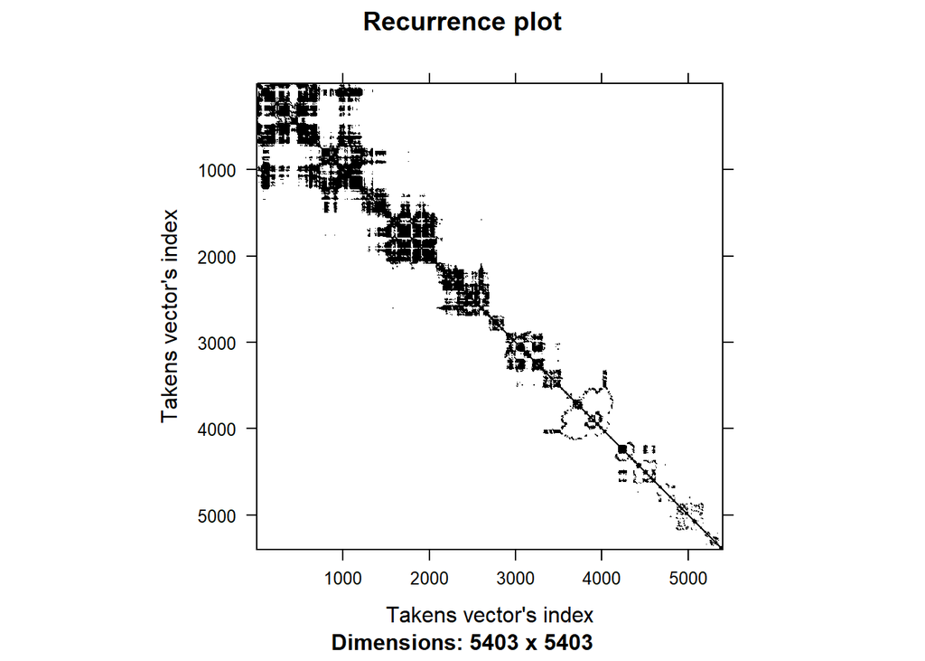

```r
rqa_HI <- (hrv.data.dn.HI$NonLinearAnalysis[[2]]$rqa[1:12])
hrv.data.dn.inf = RQA(hrv.data.dn.inf, indexNonLinearAnalysis = 2, embeddingDim = kEmbeddingDim.inf, timeLag = kTimeLag.inf, radius = 5, doPlot = TRUE)
```

```r
rqa_inf <- (hrv.data.dn.inf$NonLinearAnalysis[[2]]$rqa[1:12])
```

## Poincare plot

The Poincar? plot is a graphical representation of the dependence between successive $RR$ intervals obtained by plotting the $RR_{j+??}$ as a function of $RR_j$, being $??$ a positive integer. This dependence is often quantified by fitting an ellipse to the plot, which results in two parameters characterizing the ellipse: $SD_1$ and $SD_2$. $SD_1$ is usually calculated as the standard deviation of the points perpendicular to the line of identity, and SD2 is calculated as the standard deviation along the line of identity. Although Poincar? plots have its origin in nonlinear theory, Brennan et al. demonstrated that $SD_1$ and $SD_2$ are incapable of identifying the nonlinear beat-to-beat structure. Indeed, for $?? = 1$, it can be demonstrated that $SD_1$ and $SD_2$ can be related to linear time-domain measures:

$$SD_{1,2} = SD_1 SD_2,$$

$$SD2 = 2 \cdot SDNN^2 - \frac{1}{2}SDSD^2$$
Thus,$SD_1$ characterizes short-term variability, whereas $SD_2$ characterizes long-term variability.

In the HRV literature, when timeLag = 1, the $SD_1$ and $SD_2$ parameters are computed using time domain measures. This is the default approach in this function if timeLag=1. This function also allows the user to fit a ellipse by computing the covariance matrix of $(RR_(j)$,$RR_{(j+\tau)}$. In most cases, both approaches yield similar results.

```
##  Calculating SD1 and SD2 parameters
```

```
##  Creating Poincare Plot with time lag =  13
```

```
##  SD1 =  2.7522
```

```
##  SD2 =  11.1586
```

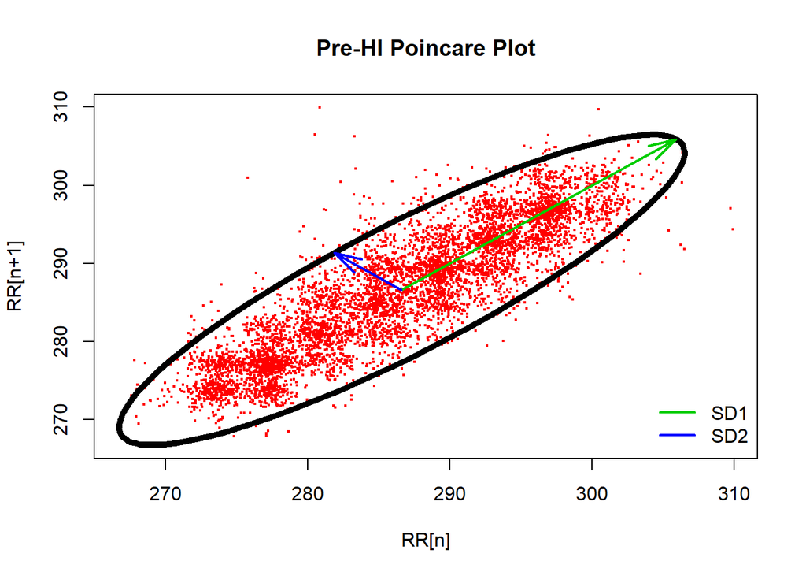

```r
# Poincare plots and fitting of the SD1-SD2 ellipse
hrv.data.dn = PoincarePlot(hrv.data.dn, indexNonLinearAnalysis = 2, timeLag = kTimeLag, confidenceEstimation = TRUE, confidence = 0.95, doPlot = TRUE, main = "Pre-HI Poincare Plot", xlab = "RR[n]", ylab = "RR[n+1]")
```

```
##  Calculating SD1 and SD2 parameters
```

```
##  Creating Poincare Plot with time lag =  13
```

```
##  SD1 =  5.7957
```

```
##  SD2 =  25.078
```

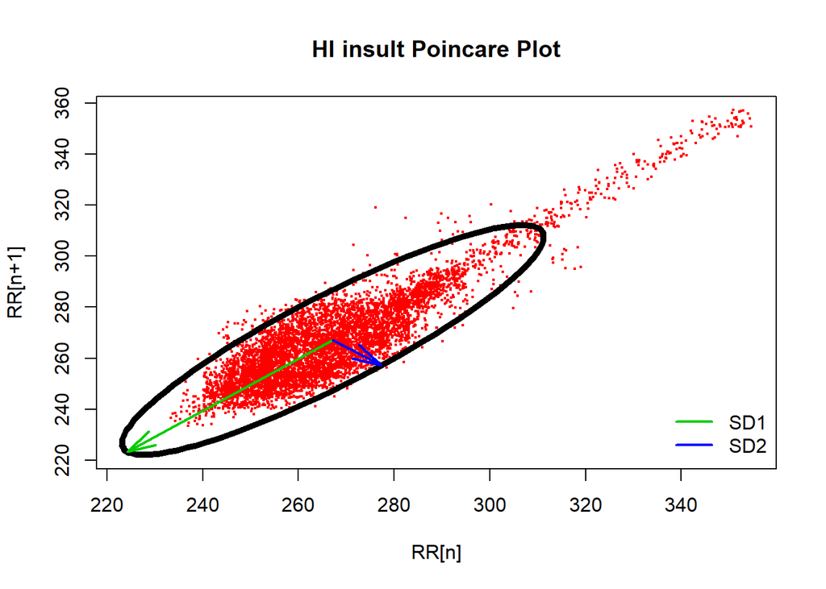

```r
NLA_pre <- c(hrv.data.dn$NonLinearAnalysis[[2]]$PoincarePlot$SD1, hrv.data.dn$NonLinearAnalysis[[2]]$PoincarePlot$SD2)

hrv.data.dn.HI = PoincarePlot(hrv.data.dn.HI, indexNonLinearAnalysis = 2, timeLag = kTimeLag, confidenceEstimation = TRUE, confidence = 0.95, doPlot = TRUE, main = "HI insult Poincare Plot", xlab = "RR[n]", ylab = "RR[n+1]")
```

```
##  Calculating SD1 and SD2 parameters
```

```
##  Creating Poincare Plot with time lag =  13
```

```
##  SD1 =  2.0471
```

```
##  SD2 =  49.2008
```

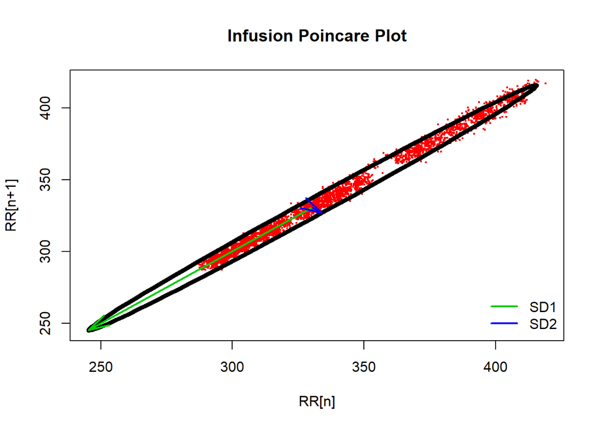

```r
NLA_HI <- c(hrv.data.dn.HI$NonLinearAnalysis[[2]]$PoincarePlot$SD1, hrv.data.dn.HI$NonLinearAnalysis[[2]]$PoincarePlot$SD2)

hrv.data.dn.inf = PoincarePlot(hrv.data.dn.inf, indexNonLinearAnalysis = 2, timeLag = kTimeLag, confidenceEstimation = TRUE, confidence = 0.95, doPlot = TRUE, main = "Infusion Poincare Plot", xlab = "RR[n]", ylab = "RR[n+1]")
```

```r
NLA_inf <- c(hrv.data.dn.inf$NonLinearAnalysis[[2]]$PoincarePlot$SD1, hrv.data.dn.inf$NonLinearAnalysis[[2]]$PoincarePlot$SD2)


Poincare_Stat <- rbind(NLA_pre, NLA_HI, NLA_inf)
colnames(Poincare_Stat) <- c("SD1", "SD2")
```

# An Overview of Fractal Dynamics

Fractal time series model some fundamental features present in RR intervals: self- affinity, power law scaling, and scale invariance. Small segments of self-affine objects when enlarged (with different scaling factors in each direction) are statistically similar to larger pieces. As a consequence of this scale invariance, when measuring a quantity $Q$ that depends on the scale s, self-affine objects manifest a remarkable property: $Q$ does not converge to a single value, but instead it exhibits a power law scaling relationship:

$$Q\alpha sH$$

and thus, $Q$ depends on the scale of measurement.

$$\frac{Q(s_1)}{Q(s2)}= (\frac{s1}{s2})^H$$

Eke et al. proposed a dichotomous model in which physiological signals are seen as realizations of one of two temporal processes: fractional Brownian motion $(fBm)$ and fractional Gaussian noise$(fGn)$. The self-affinity and the appearance of both $fBm$ and $fGn$ are controlled by a single parameter, the Hurst exponent $0 < H < 1$. $fBm$- signals are nonstationary. A $fBm-signal$ with a $H$ close to 1 describes a smooth signal, whereas a $fBm-signal$ with $H$ close to 0 describes a rough signal. The increments of a nonstationary $fBm$ yield a stationary $fGn$. Thus, I can transform a $fBm-signal$ in a $fGn-signal$ by differencing, and I can transform a $fGn-signal$ in a $fBm-signal$ by cumulative summation. The $H$ exponent of a $fGn$ can be easily interpreted:

. If $H < 1/2$, the process is anti-correlated (negatively correlated). . If $H = 1/2$, the process is uncorrelated (white noise). The cumulative summation

of white noise yields Brownian motion $(fBm with H = 1/2)$. . If $H > 1/2$, the process is positively correlated.

The next sections provide a brief overview of the most important tools for estimat- ing the Hurst exponent, included in RHRV. Note that the Hurst exponent is between 0 and 1 regardless of the model. Thus, to avoid possible mistakes, when reporting values of $H$, the class of the signal should always be specified $(as HfBm or Hf Gn)$. Note that this section focuses on monofractal models. However, there exist evidence supporting the application of multifractal models to HRV.

## Power Spectral Density

The power spectrum of a fractal signal fulfils the power law relationship

$$S(\omega) = C\omega^{-\beta} ,$$
where is the spectral index. Signals with this type of power spectrum are referred to as $1/f$ noises. $1/f$ noises with -1 < $\beta$ < 1 and 1 < $\beta$ < 3 can be approximated by fGn and fBm-signals, respectively.

From the equation above, it is clear that we may estimate $\beta$ using regression. The high frequency part of the spectrum is usually discarded before fitting the regression line, since in practical applications the power law behavior holds only for frequencies close to zero. The resulting estimation, $\beta$, can be used for discriminating the signal class. If $\beta$ < 1, then the signal is a fGn, whereas if $\beta$ > 1, the signal is a fBm.

If $\beta$ $\approx 1$, there is uncertainty about the nature of the signal. Once the signal has been classified, the Hurst exponent may be obtained using either:

$$\hat{\beta} = 2 \hat{H}_{f B m} + 1$$
or

$$\hat{\beta} = 2\hat{H}_{fGn} - 1 .$$

```
##  Calculating spectral index
```

```
##  Plotting PSD
```

```
##  Spectral index = 2.1753
```

```
##  H_fBm = 0.5876
```

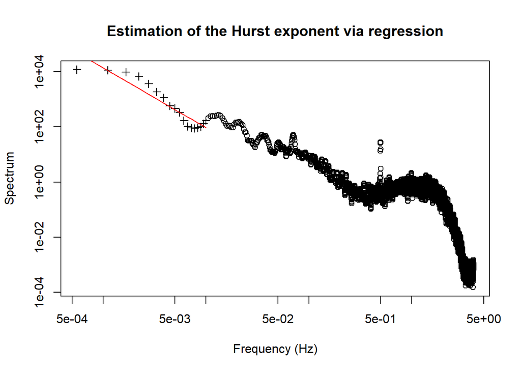

```r
# The slope of the PSD is be used to calculate the Hurst exponent
hrv.data.pre <- EstimatePSDSlope(hrv.data.pre, indexFreqAnalysis = 1, regressionRange = NULL, doPlot = T, main = "Estimation of the Hurst exponent via regression", xlab = "Frequency (Hz)", ylab = "Spectrum")
```

```
##  Calculating spectral index
```

```
##  Plotting PSD
```

```
##  Spectral index = 1.142
```

```
##  H_fBm = 0.071
```

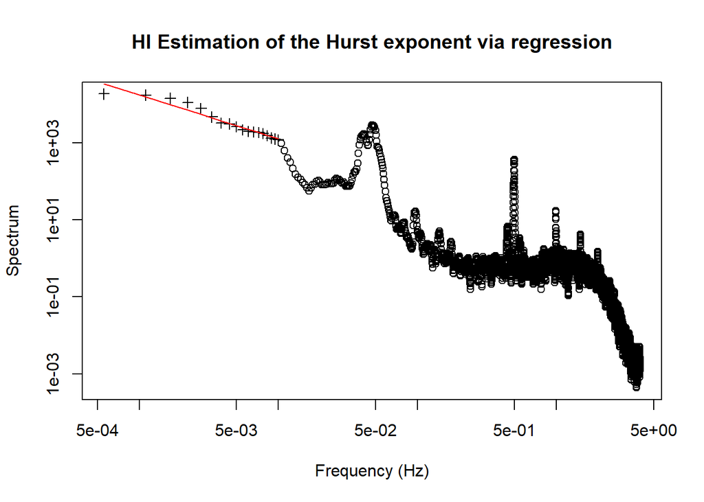

```r
hrv.data.HI <- EstimatePSDSlope(hrv.data.HI, indexFreqAnalysis = 1, regressionRange = NULL, doPlot = T, main = "HI Estimation of the Hurst exponent via regression", xlab = "Frequency (Hz)", ylab = "Spectrum")
```

```
##  Calculating spectral index
```

```
##  Plotting PSD
```

```
##  Spectral index = 1.8685
```

```
##  H_fBm = 0.4343
```

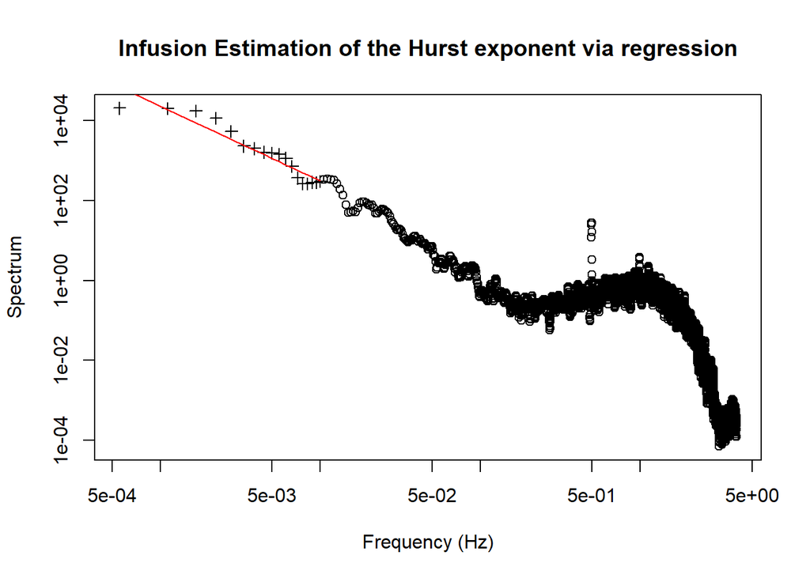

```r
hrv.data.inf <- EstimatePSDSlope(hrv.data.inf, indexFreqAnalysis = 1, regressionRange = NULL, doPlot = T, main = "Infusion Estimation of the Hurst exponent via regression", xlab = "Frequency (Hz)", ylab = "Spectrum")
```

## Detrended Fluctuation analysis

Mandelbrot introduced a Hurst estimation technique, named scaled windowed variance analysis $(SWV)$. Peng et al. further developed $SWV$ to improve the analysis of nonstationary data. This method is now referred to as detrended fluctuation analysis $(DFA)$. The DFA algorithm proceeds as follows:

1. The signal to be analyzed $x$ is asummed (the mean is substracted to avoid obtaining a monotonic signal):
   $$y_i = \sum^{i}_{k=1}{x_k-\mu}$$
   The resulting time series $y$ is usually referred to as the profile.
2. The profile is divided into nonoverlapping segments of length $n$. Then, the local trend $y_{i,n}$ in each of the segments is estimated using least-square regression.
3. The average fluctuation of the data relative to the local trend is computed:
   $$F_n = \sqrt{\frac{1}{N}\sum^{N}_{j=1} (y_j=y_{j,n})$$
4. Repeat steps 1-3 for different window sizes to obtain the so-called fluctuation function $F_n$.
5. If the data is self-affine $F_n \alpha n^\alpha$, and the scaling exponent $\alpha$ is estimated using regression. The estimated scaling exponent, $\hat{\alpha}$ , can be used for discriminating the signal nature. If $\hat{\alpha} < 1$, then the signal is $fGn$ and $\hat{\alpha} = H^fGn$, whereas if $\hat{\alpha} > 1$, the signal is $fBm$ with $\hat{\alpha} = H^$ $fBm + 1$. If $\hat{\alpha} \approx 1$, there is uncertainty about the nature of the signal.

The Detrended Fluctuation Analysis $(DFA)$ has become a widely used technique for detecting long range correlations in time series. The $DFA$ procedure may be summarized as follows:

1. Integrate the time series to be analyzed. The time series resulting from the integration will be referred to as the profile.
2. Divide the profile into $N$ non-overlapping segments.
3. Calculate the local trend for each of the segments using least-square regression. Compute the total error for each of the segments.
4. Compute the average of the total error over all segments and take its root square. By repeating the previous steps for several segment sizes (let’s denote it by $t$), the so-called Fluctuation function $F(t)$ can be obtained.
5. If the data presents long-range power law correlations: $F(t)$ proportional $t^\alpha$ and I may estimate using regression.
6. Usually, when plotting $log{(F(t)}$) Vs $log(t)$ we may distinguish two linear regions. By regression them separately, we obtain two scaling exponents, $\alpha1$ (characterizing short-term fluctuations) and $\alpha2$ (characterizing long-term fluctuations).

```
##  Performing Detrended Fluctuation Analysis
```

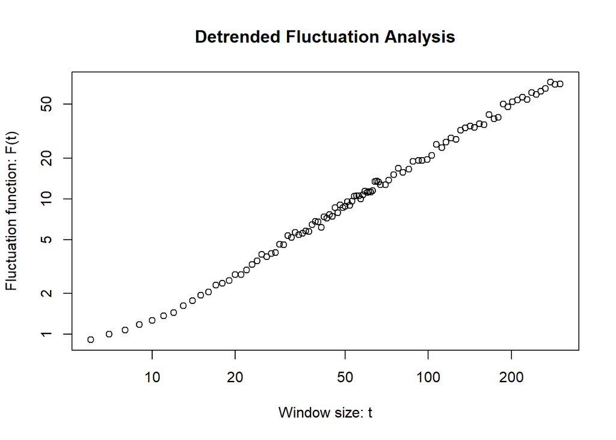

```r
# Calculate the detrended fluctuation analysis
hrv.data.dn = CalculateDFA(hrv.data.dn, indexNonLinearAnalysis = 2, windowSizeRange = c(6,300),
                     npoints = 100, doPlot = TRUE)
```

```
##  Performing Detrended Fluctuation Analysis
```

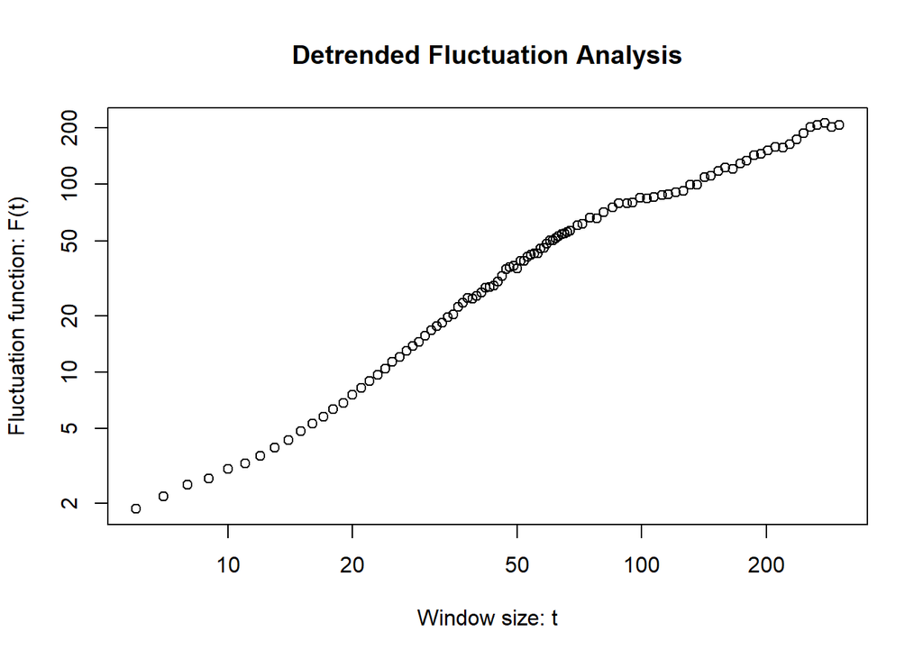

```r
hrv.data.dn.HI = CalculateDFA(hrv.data.dn.HI, indexNonLinearAnalysis = 2, windowSizeRange = c(6,300),
                     npoints = 100, doPlot = TRUE)
```

```
##  Performing Detrended Fluctuation Analysis
```

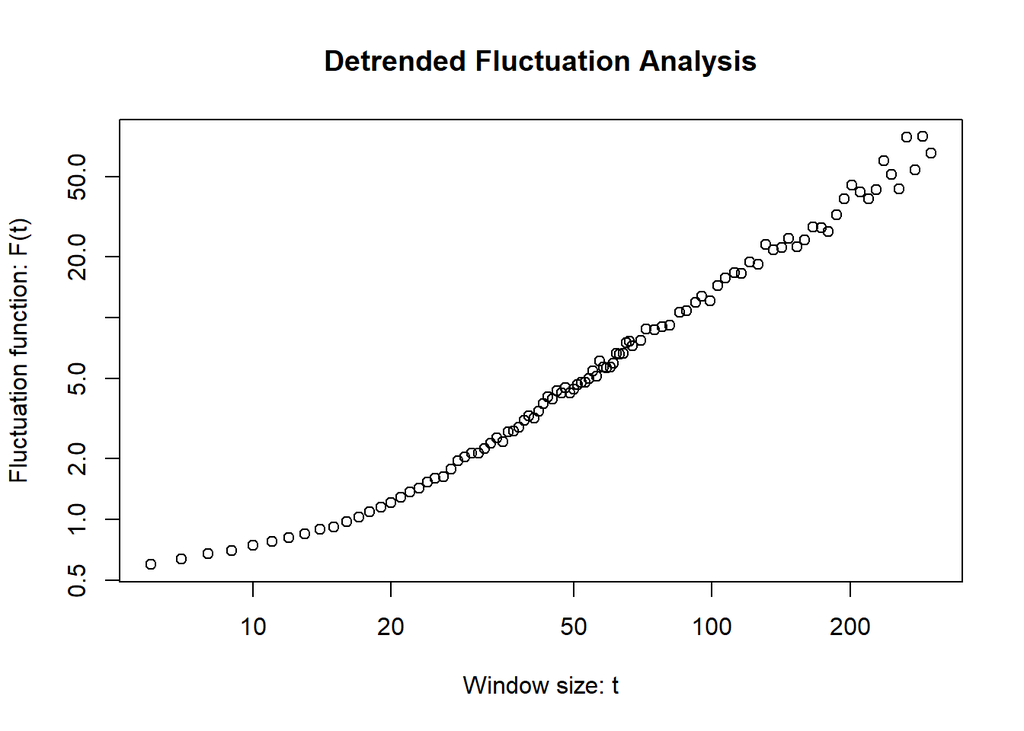

```r
hrv.data.dn.inf = CalculateDFA(hrv.data.dn.inf, indexNonLinearAnalysis = 2, windowSizeRange = c(6,300),
                     npoints = 100, doPlot = TRUE)
```

```
##  Estimating Scaling exponent
```

```
##  Scaling Exponent number 1 = 0.8045
```

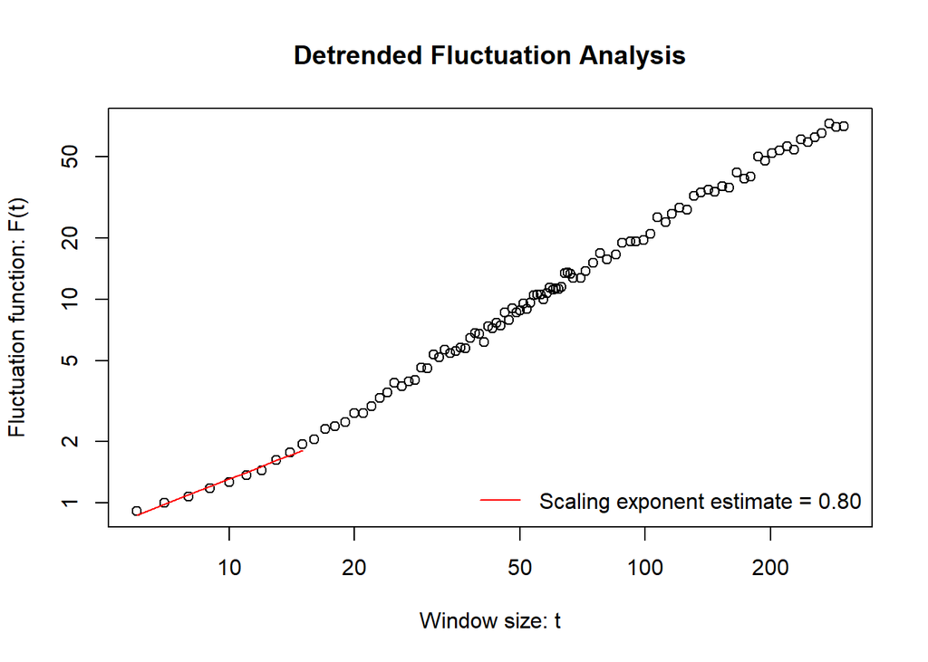

```r
#Most of the time there exists two linear regions, so two scaling exponents will be calculated

hrv.data.dn = EstimateDFA(hrv.data.dn, indexNonLinearAnalysis = 2,
                    regressionRange = c(5,15), doPlot = TRUE)
```

```
##  Estimating Scaling exponent
```

```
##  Scaling Exponent number 2 = 1.2711
```

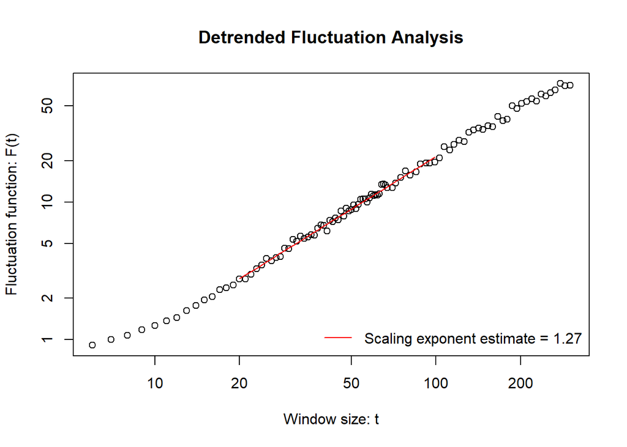

```r
hrv.data.dn = EstimateDFA(hrv.data.dn, indexNonLinearAnalysis = 2,
                    regressionRange = c(20,100), doPlot = TRUE)
```

```
##  Estimating Scaling exponent
```

```
##  Scaling Exponent number 1 = 0.998
```

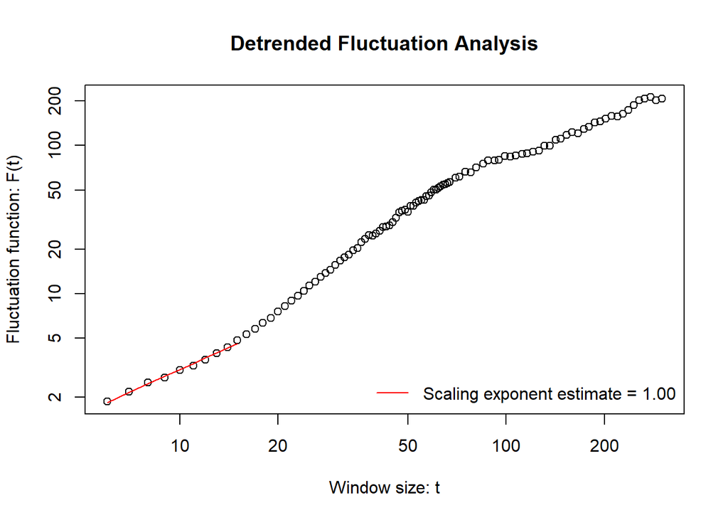

```r
hrv.data.dn.HI = EstimateDFA(hrv.data.dn.HI, indexNonLinearAnalysis = 2,
                    regressionRange = c(5,15), doPlot = TRUE)
```

```
##  Estimating Scaling exponent
```

```
##  Scaling Exponent number 2 = 1.5646
```

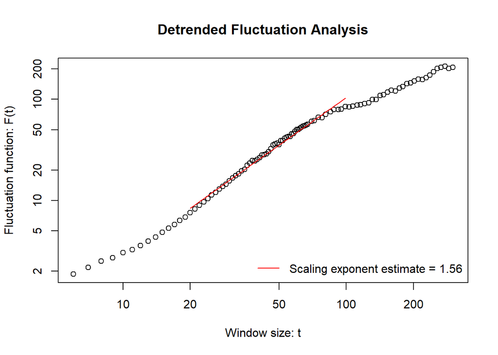

```r
hrv.data.dn.HI = EstimateDFA(hrv.data.dn.HI, indexNonLinearAnalysis = 2,
                    regressionRange = c(20,100), doPlot = TRUE)
```

```
##  Estimating Scaling exponent
```

```
##  Scaling Exponent number 1 = 0.4748
```

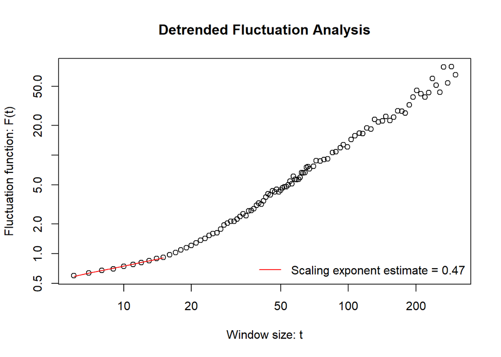

```r
hrv.data.dn.inf = EstimateDFA(hrv.data.dn.inf, indexNonLinearAnalysis = 2,
                    regressionRange = c(5,15), doPlot = TRUE)
```

```
##  Estimating Scaling exponent
```

```
##  Scaling Exponent number 2 = 1.5242
```

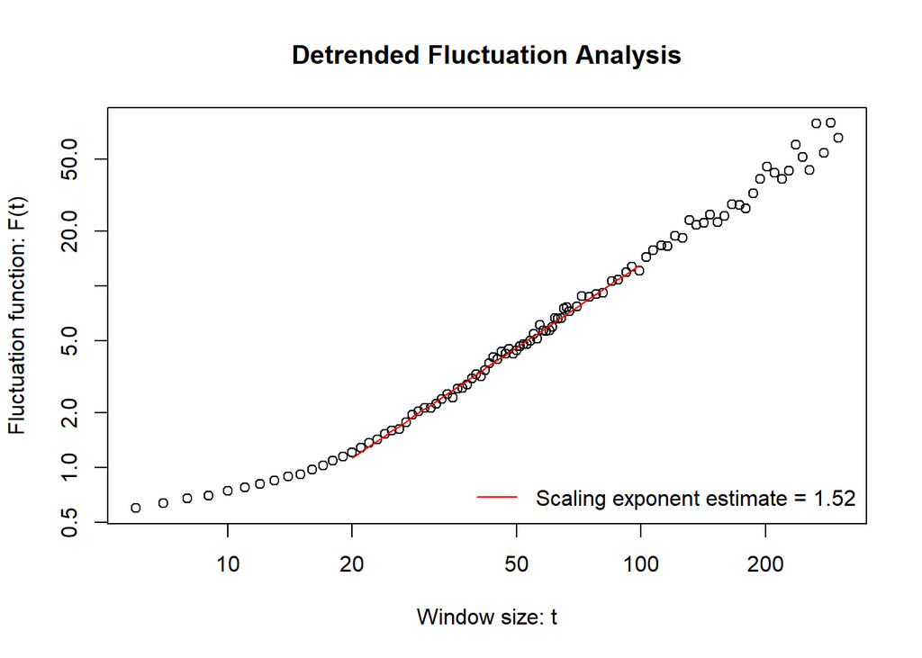

```r
hrv.data.dn.inf = EstimateDFA(hrv.data.dn.inf, indexNonLinearAnalysis = 2,
                    regressionRange = c(20,100), doPlot = TRUE)
```

The data from this report will be compiled into a spreadsheet in wide format, combined with the remaining piglets and analysed further.

```r
WriteToFile(hrv.data.pre, "2334_RR_pre_HRV", overwrite = TRUE)
```

```
##  Writing file: 2334_RR_pre_HRV.hrv
```

```
##  File 2334_RR_pre_HRV.hrv already exists
```

```
##  2670595 bytes written
```

```r
WriteToFile(hrv.data.HI, "2334_RR_HI_HRV", overwrite = TRUE)
```

```
##  Writing file: 2334_RR_HI_HRV.hrv
```

```
##  File 2334_RR_HI_HRV.hrv already exists
```

```
##  2717553 bytes written
```

```r
WriteToFile(hrv.data.inf, "2334_RR_inf_HRV", overwrite = TRUE)
```

```
##  Writing file: 2334_RR_inf_HRV.hrv
```

```
##  File 2334_RR_inf_HRV.hrv already exists
```

```
##  2669228 bytes written
```